# PART- A

DOMAIN: Electronics and Telecommunication

• CONTEXT: A communications equipment manufacturing company has a product which is responsible for emitting informative signals. Company wants to build a machine learning model which can help the company to predict the equipment’s signal quality using various parameters.

• DATA DESCRIPTION: The data set contains information on various signal tests performed:

1. Parameters: Various measurable signal parameters.
2. Signal_Quality: Final signal strength or quality

• PROJECT OBJECTIVE: The need is to build a regressor which can use these parameters to determine the signal strength or quality [as number]

### Steps and tasks:

## 1. Import data.

### Part1.1a-Read the ‘Signals.csv’ as DataFrame and import required libraries

```python
import pandas as pd
import numpy as np
import matplotlib.pyplot as plt
import seaborn as sns
from sklearn.model_selection import train_test_split
import tensorflow as tf
from tensorflow.keras.utils import to_categorical
from tensorflow.keras.layers import Dense, Reshape, BatchNormalization, Dropout
from tensorflow.keras.models import Sequential
from tensorflow.keras import regularizers, optimizers
from sklearn.metrics import classification_report, accuracy_score, confusion_matrix, precision_score, recall_score, f1_score, precision_recall_curve
```

```python
signaldata=pd.read_csv("Part- 1 - Signal.csv")
signaldata.head()
```

|  | Parameter 1 | Parameter 2 | Parameter 3 | Parameter 4 | Parameter 5 | Parameter 6 | Parameter 7 | Parameter 8 | Parameter 9 | Parameter 10 | Parameter 11 | Signal_Strength |
| --- | --- | --- | --- | --- | --- | --- | --- | --- | --- | --- | --- | --- |
| 0 | 7.4 | 0.70 | 0.00 | 1.9 | 0.076 | 11.0 | 34.0 | 0.9978 | 3.51 | 0.56 | 9.4 | 5 |
| 1 | 7.8 | 0.88 | 0.00 | 2.6 | 0.098 | 25.0 | 67.0 | 0.9968 | 3.20 | 0.68 | 9.8 | 5 |
| 2 | 7.8 | 0.76 | 0.04 | 2.3 | 0.092 | 15.0 | 54.0 | 0.9970 | 3.26 | 0.65 | 9.8 | 5 |
| 3 | 11.2 | 0.28 | 0.56 | 1.9 | 0.075 | 17.0 | 60.0 | 0.9980 | 3.16 | 0.58 | 9.8 | 6 |
| 4 | 7.4 | 0.70 | 0.00 | 1.9 | 0.076 | 11.0 | 34.0 | 0.9978 | 3.51 | 0.56 | 9.4 | 5 |

```python
signaldata.shape
```

```
(1599, 12)
```

### Part1.1b -Check for missing values and print percentage for each attribute

```python
print ("Missing value percentage :\n\n",signaldata.isnull().sum()/signaldata.shape[0])
```

```
Missing value percentage :

 Parameter 1        0.0
Parameter 2        0.0
Parameter 3        0.0
Parameter 4        0.0
Parameter 5        0.0
Parameter 6        0.0
Parameter 7        0.0
Parameter 8        0.0
Parameter 9        0.0
Parameter 10       0.0
Parameter 11       0.0
Signal_Strength    0.0
dtype: float64
```

### Part1.1c -Check for presence of duplicate records in the dataset and impute with appropriate method

```python
signaldata.duplicated().sum()
```

```
240
```

```python
#Dropping duplicates

signaldata.drop_duplicates(inplace=True)
```

```python
signaldata.shape
```

```
(1359, 12)
```

# 2. Data analysis & visualisation

• Perform relevant and detailed statistical analysis on the data.

• Perform relevant and detailed uni, bi and multi variate analysis.

Hint: Use your best analytical approach. Even you can mix match columns to create new columns which can be used for better analysis. Create your own features if required. Be highly experimental and analytical here to find relevant hidden patterns.

## Univariate Analysis

### Part1.1d-Visualise distribution of the target variable

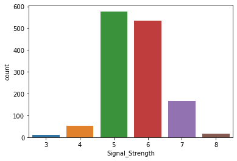

```python
sns.countplot(x=signaldata['Signal_Strength'])
```

```python
signaldata['Signal_Strength'].value_counts()/len(signaldata['Signal_Strength'])
```

```
5    0.424577
6    0.393672
7    0.122884
4    0.038999
8    0.012509
3    0.007358
Name: Signal_Strength, dtype: float64
```

**Insights**

1. Data is imbalanced.
2. 80% of data have Signal strength 5 and 6
3. 12% of data are 7
4. 4,8,3 signal strength are minority.

### Part1.1e--Share insights from the initial data analysis (at least 2)

### Statistical analysis

```python
signaldata.info()
```

```
<class 'pandas.core.frame.DataFrame'>
Int64Index: 1359 entries, 0 to 1598
Data columns (total 12 columns):
 #   Column           Non-Null Count  Dtype
---  ------           --------------  -----
 0   Parameter 1      1359 non-null   float64
 1   Parameter 2      1359 non-null   float64
 2   Parameter 3      1359 non-null   float64
 3   Parameter 4      1359 non-null   float64
 4   Parameter 5      1359 non-null   float64
 5   Parameter 6      1359 non-null   float64
 6   Parameter 7      1359 non-null   float64
 7   Parameter 8      1359 non-null   float64
 8   Parameter 9      1359 non-null   float64
 9   Parameter 10     1359 non-null   float64
 10  Parameter 11     1359 non-null   float64
 11  Signal_Strength  1359 non-null   int64
dtypes: float64(11), int64(1)
memory usage: 170.3 KB
```

1. 1359 rows of data .
2. There are 12 features , 11 features are float and signal strength is integer
3. There are no null values

```python
signaldata.describe()
```

|  | Parameter 1 | Parameter 2 | Parameter 3 | Parameter 4 | Parameter 5 | Parameter 6 | Parameter 7 | Parameter 8 | Parameter 9 | Parameter 10 | Parameter 11 | Signal_Strength |
| --- | --- | --- | --- | --- | --- | --- | --- | --- | --- | --- | --- | --- |
| count | 1359.000000 | 1359.000000 | 1359.000000 | 1359.000000 | 1359.000000 | 1359.000000 | 1359.000000 | 1359.000000 | 1359.000000 | 1359.000000 | 1359.000000 | 1359.000000 |
| mean | 8.310596 | 0.529478 | 0.272333 | 2.523400 | 0.088124 | 15.893304 | 46.825975 | 0.996709 | 3.309787 | 0.658705 | 10.432315 | 5.623252 |
| std | 1.736990 | 0.183031 | 0.195537 | 1.352314 | 0.049377 | 10.447270 | 33.408946 | 0.001869 | 0.155036 | 0.170667 | 1.082065 | 0.823578 |
| min | 4.600000 | 0.120000 | 0.000000 | 0.900000 | 0.012000 | 1.000000 | 6.000000 | 0.990070 | 2.740000 | 0.330000 | 8.400000 | 3.000000 |
| 25% | 7.100000 | 0.390000 | 0.090000 | 1.900000 | 0.070000 | 7.000000 | 22.000000 | 0.995600 | 3.210000 | 0.550000 | 9.500000 | 5.000000 |
| 50% | 7.900000 | 0.520000 | 0.260000 | 2.200000 | 0.079000 | 14.000000 | 38.000000 | 0.996700 | 3.310000 | 0.620000 | 10.200000 | 6.000000 |
| 75% | 9.200000 | 0.640000 | 0.430000 | 2.600000 | 0.091000 | 21.000000 | 63.000000 | 0.997820 | 3.400000 | 0.730000 | 11.100000 | 6.000000 |
| max | 15.900000 | 1.580000 | 1.000000 | 15.500000 | 0.611000 | 72.000000 | 289.000000 | 1.003690 | 4.010000 | 2.000000 | 14.900000 | 8.000000 |

### Dist plot for all features

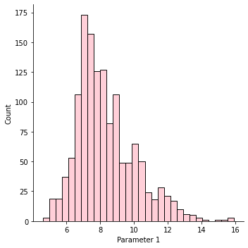

```
Distribution of  Parameter 1
Mean is: 8.310596026490087
Median is: 7.9
Mode is: 0    7.2
dtype: float64
Standard deviation is: 1.736989807532466
Skewness is: 0.9410413664561449
Maximum is: 15.9
Minimum is: 4.6
```

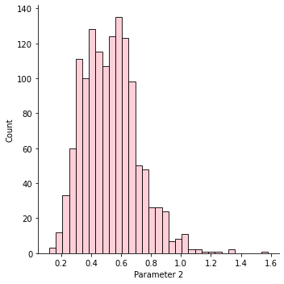

```
Distribution of  Parameter 2
Mean is: 0.5294775570272258
Median is: 0.52
Mode is: 0    0.5
dtype: float64
Standard deviation is: 0.18303131761907185
Skewness is: 0.7292789463991854
Maximum is: 1.58
Minimum is: 0.12
```

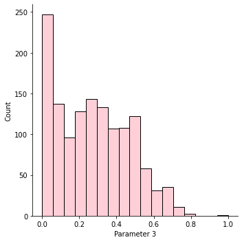

```
Distribution of  Parameter 3
Mean is: 0.27233259749815975
Median is: 0.26
Mode is: 0    0.0
dtype: float64
Standard deviation is: 0.1955365445504639
Skewness is: 0.31272554238899036
Maximum is: 1.0
Minimum is: 0.0
```

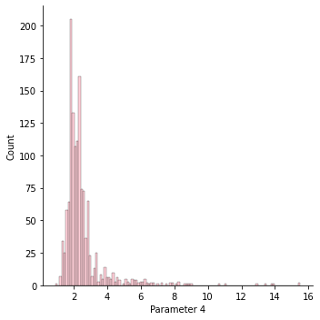

```
Distribution of  Parameter 4
Mean is: 2.523399558498897
Median is: 2.2
Mode is: 0    2.0
dtype: float64
Standard deviation is: 1.3523137577104198
Skewness is: 4.548153403940447
Maximum is: 15.5
Minimum is: 0.9
```

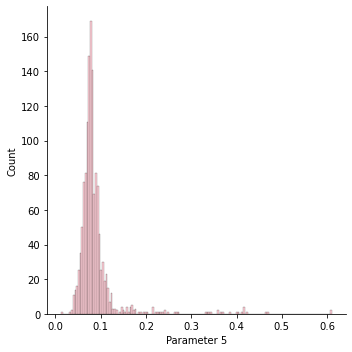

```
Distribution of  Parameter 5
Mean is: 0.0881236203090504
Median is: 0.079
Mode is: 0    0.08
dtype: float64
Standard deviation is: 0.04937686244348626
Skewness is: 5.502487294623722
Maximum is: 0.611
Minimum is: 0.012
```

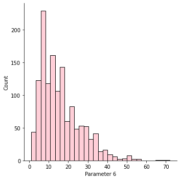

```
Distribution of  Parameter 6
Mean is: 15.893303899926417
Median is: 14.0
Mode is: 0    6.0
dtype: float64
Standard deviation is: 10.447270259048695
Skewness is: 1.2265794991760643
Maximum is: 72.0
Minimum is: 1.0
```

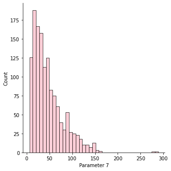

```
Distribution of  Parameter 7
Mean is: 46.82597498160412
Median is: 38.0
Mode is: 0    28.0
dtype: float64
Standard deviation is: 33.40894570661654
Skewness is: 1.5403680777213933
Maximum is: 289.0
Minimum is: 6.0
```

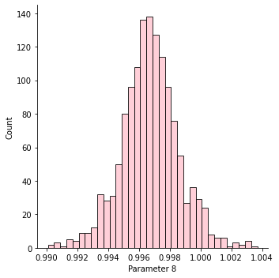

```
Distribution of  Parameter 8
Mean is: 0.9967089477557026
Median is: 0.9967
Mode is: 0    0.9968
dtype: float64
Standard deviation is: 0.0018689171325591398
Skewness is: 0.04477785573116107
Maximum is: 1.00369
Minimum is: 0.99007
```

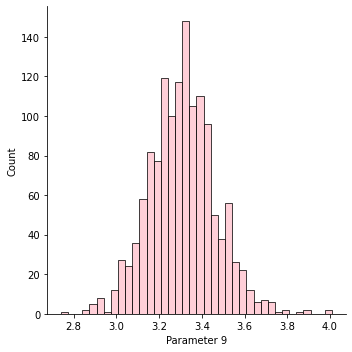

```
Distribution of  Parameter 9
Mean is: 3.309786607799856
Median is: 3.31
Mode is: 0    3.3
dtype: float64
Standard deviation is: 0.15503631128729595
Skewness is: 0.2320322752014824
Maximum is: 4.01
Minimum is: 2.74
```

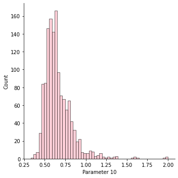

```
Distribution of  Parameter 10
Mean is: 0.6587049300956593
Median is: 0.62
Mode is: 0    0.54
dtype: float64
Standard deviation is: 0.17066689057420695
Skewness is: 2.4065046145674196
Maximum is: 2.0
Minimum is: 0.33
```

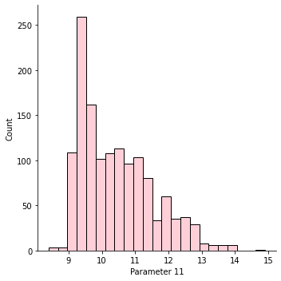

```
Distribution of  Parameter 11
Mean is: 10.432315428013228
Median is: 10.2
Mode is: 0    9.5
dtype: float64
Standard deviation is: 1.0820654499497833
Skewness is: 0.8598411692319623
Maximum is: 14.9
Minimum is: 8.4
```

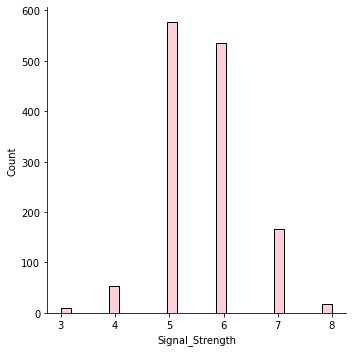

```
Distribution of  Signal_Strength
Mean is: 5.6232523914643116
Median is: 6.0
Mode is: 0    5
dtype: int64
Standard deviation is: 0.8235780017165619
Skewness is: 0.19240658731658308
Maximum is: 8
Minimum is: 3
```

```python
cols = list(signaldata)
for i in np.arange(len(cols)):
    sns.displot(signaldata[cols[i]], color='pink')
    plt.show()
    print('Distribution of ',cols[i])
    print('Mean is:',signaldata[cols[i]].mean())
    print('Median is:',signaldata[cols[i]].median())
    print('Mode is:',signaldata[cols[i]].mode())
    print('Standard deviation is:',signaldata[cols[i]].std())
    print('Skewness is:',signaldata[cols[i]].skew())
    print('Maximum is:',signaldata[cols[i]].max())
    print('Minimum is:',signaldata[cols[i]].min())
```

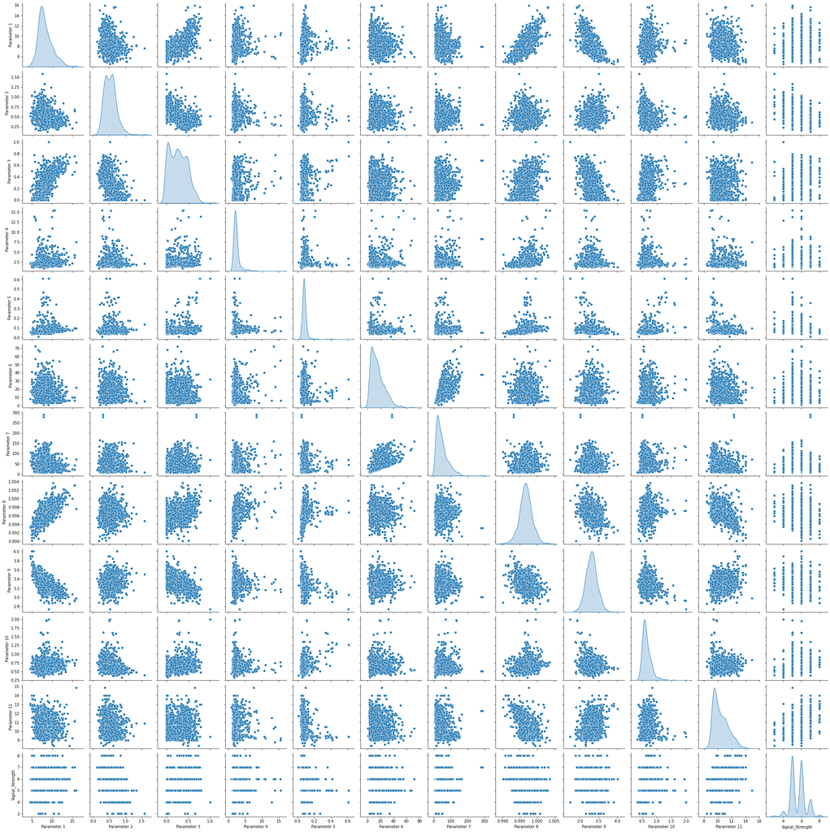

```python
sns.pairplot(signaldata,diag_kind='kde')
```

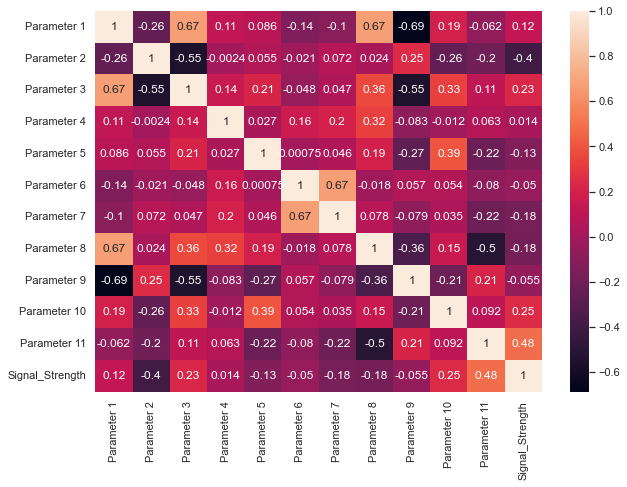

```python
sns.set(rc={"figure.figsize":(10, 7)})
sns.heatmap(signaldata.corr(),annot=True)
```

Maximun positive Correlation is between Param 1 and 3, 1 and 8 and 6 and 7 with 0.67

Parameter 1 and 9 are negative correlation.

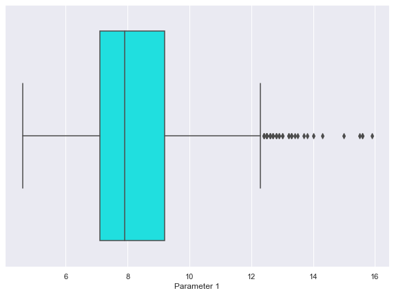

```
Boxplot of  Parameter 1
Q1 is :  7.1
Q2 is :  7.9
Q3 is :  9.2
IQR is: 2.0999999999999996
Lower Whisker, Upper Whisker :  3.95 , 12.349999999999998
Out of  1359  rows in data, number of outliers are: 41
```

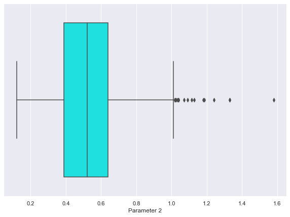

```
Boxplot of  Parameter 2
Q1 is :  0.39
Q2 is :  0.52
Q3 is :  0.64
IQR is: 0.25
Lower Whisker, Upper Whisker :  0.015000000000000013 , 1.0150000000000001
Out of  1359  rows in data, number of outliers are: 19
```

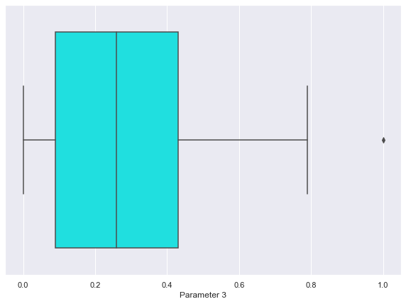

```
Boxplot of  Parameter 3
Q1 is :  0.09
Q2 is :  0.26
Q3 is :  0.43
IQR is: 0.33999999999999997
Lower Whisker, Upper Whisker :  -0.42000000000000004 , 0.94
Out of  1359  rows in data, number of outliers are: 1
```

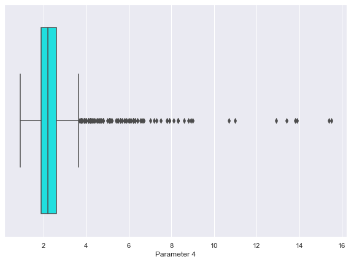

```
Boxplot of  Parameter 4
Q1 is :  1.9
Q2 is :  2.2
Q3 is :  2.6
IQR is: 0.7000000000000002
Lower Whisker, Upper Whisker :  0.8499999999999996 , 3.6500000000000004
Out of  1359  rows in data, number of outliers are: 126
```

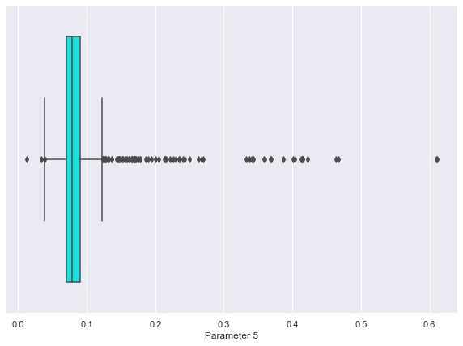

```
Boxplot of  Parameter 5
Q1 is :  0.07
Q2 is :  0.079
Q3 is :  0.091
IQR is: 0.02099999999999999
Lower Whisker, Upper Whisker :  0.03850000000000002 , 0.12249999999999998
Out of  1359  rows in data, number of outliers are: 87
```

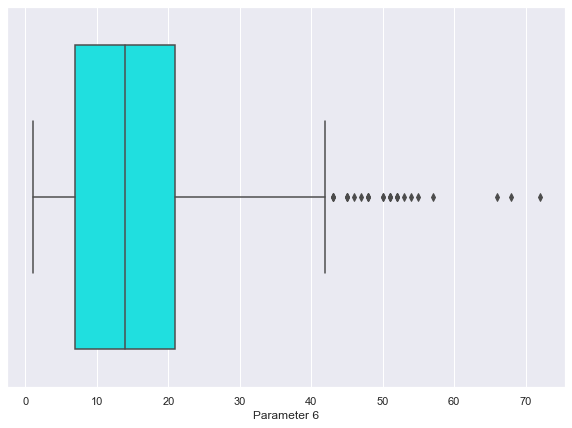

```
Boxplot of  Parameter 6
Q1 is :  7.0
Q2 is :  14.0
Q3 is :  21.0
IQR is: 14.0
Lower Whisker, Upper Whisker :  -14.0 , 42.0
Out of  1359  rows in data, number of outliers are: 26
```

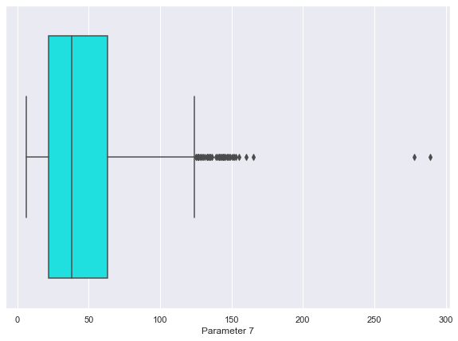

```
Boxplot of  Parameter 7
Q1 is :  22.0
Q2 is :  38.0
Q3 is :  63.0
IQR is: 41.0
Lower Whisker, Upper Whisker :  -39.5 , 124.5
Out of  1359  rows in data, number of outliers are: 45
```

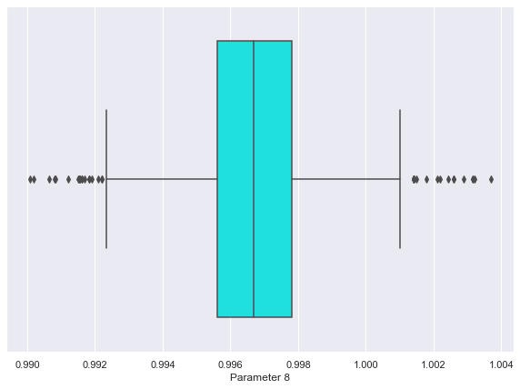

```
Boxplot of  Parameter 8
Q1 is :  0.9956
Q2 is :  0.9967
Q3 is :  0.99782
IQR is: 0.0022199999999999998
Lower Whisker, Upper Whisker :  0.99227 , 1.00115
Out of  1359  rows in data, number of outliers are: 35
```

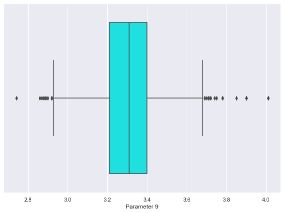

```
Boxplot of  Parameter 9
Q1 is :  3.21
Q2 is :  3.31
Q3 is :  3.4
IQR is: 0.18999999999999995
Lower Whisker, Upper Whisker :  2.925 , 3.6849999999999996
Out of  1359  rows in data, number of outliers are: 28
```

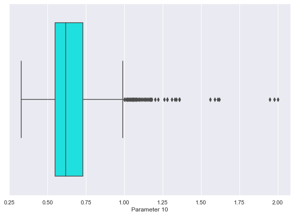

```
Boxplot of  Parameter 10
Q1 is :  0.55
Q2 is :  0.62
Q3 is :  0.73
IQR is: 0.17999999999999994
Lower Whisker, Upper Whisker :  0.28000000000000014 , 0.9999999999999999
Out of  1359  rows in data, number of outliers are: 55
```

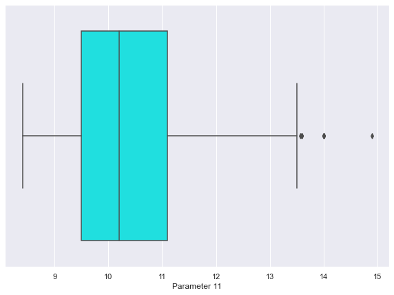

```
Boxplot of  Parameter 11
Q1 is :  9.5
Q2 is :  10.2
Q3 is :  11.1
IQR is: 1.5999999999999996
Lower Whisker, Upper Whisker :  7.1000000000000005 , 13.5
Out of  1359  rows in data, number of outliers are: 12
```

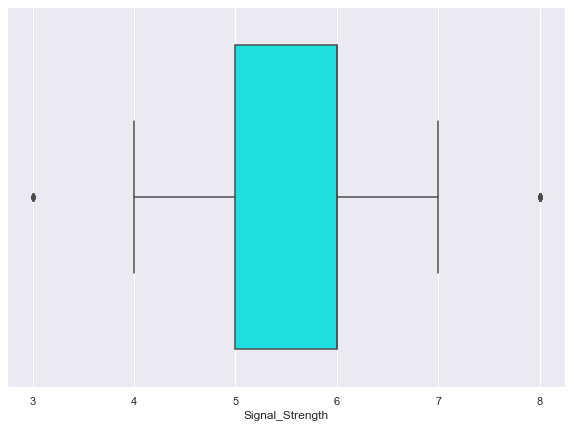

```
Boxplot of  Signal_Strength
Q1 is :  5.0
Q2 is :  6.0
Q3 is :  6.0
IQR is: 1.0
Lower Whisker, Upper Whisker :  3.5 , 7.5
Out of  1359  rows in data, number of outliers are: 27
```

```python
# Checking the presence of outliers
l = len(signaldata)
col = list(signaldata.columns)
for i in np.arange(len(col)):
    sns.boxplot(x= signaldata[col[i]], color='cyan')
    plt.show()
    print('Boxplot of ',col[i])
    #calculating the outiers in attribute
    Q1 = signaldata[col[i]].quantile(0.25)
    Q2 = signaldata[col[i]].quantile(0.50)
    Q3 = signaldata[col[i]].quantile(0.75)
    IQR = Q3 - Q1
    L_W = (Q1 - 1.5 *IQR)
    U_W = (Q3 + 1.5 *IQR)
    print('Q1 is : ',Q1)
    print('Q2 is : ',Q2)
    print('Q3 is : ',Q3)
    print('IQR is:',IQR)
    print('Lower Whisker, Upper Whisker : ',L_W,',',U_W)
    bools = (signaldata[col[i]] < (Q1 - 1.5 *IQR)) |(signaldata[col[i]] > (Q3 + 1.5 * IQR))
    print('Out of ',l,' rows in data, number of outliers are:',bools.sum())   #ca
```

### Part1.2a-Split the data into X & Y

```python
xwithnoise = signaldata.drop("Signal_Strength", axis=1)
Y = signaldata['Signal_Strength']
```

Imputing Outliers in X variables

```python
# Replace every outlier on the lower side by the lower whisker
def outlier_treatment(Q1,Q3,IQR,data):
    for i, j in zip(np.where(data < Q1 - 1.5 * IQR)[0], np.where(data < Q1 - 1.5 * IQR)[1]):
        whisker  = Q1 - 1.5 * IQR
        data.iloc[i,j] = whisker[j]


    #Replace every outlier on the upper side by the upper whisker
    for i, j in zip(np.where(data > Q3 + 1.5 * IQR)[0], np.where(data > Q3 + 1.5 * IQR)[1]):
        whisker  = Q3 + 1.5 * IQR
        data.iloc[i,j] = whisker[j]
    return data


Q1 = xwithnoise.quantile(0.25)
Q3 = xwithnoise.quantile(0.75)
IQR = Q3 - Q1
X=outlier_treatment(Q1,Q3,IQR,xwithnoise)
```

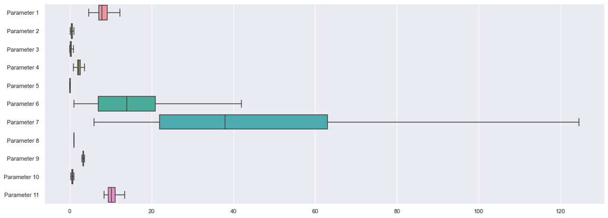

```python
#afer outlier removal
fig = plt.figure(figsize = (19, 7))
ax = sns.boxplot(data = X, orient = 'h')
```

### Part 1.2 b -Split the data into train & test with 70:30 proportion

```python
X_train, X_test, Y_train, Y_test = train_test_split(X, Y,train_size=0.7, random_state=12)
```

### Part1.2c-Print shape of all the 4 variables and verify if train and test data is in sync.

```python
print(" X_Train",X_train.shape)
print(" Y_train",Y_train.shape)
print(" X_test",X_test.shape)
print(" Y_test",Y_test.shape)
```

```
 X_Train (951, 11)
 Y_train (951,)
 X_test (408, 11)
 Y_test (408,)
```

```python
if(X_train.shape[1]==X_test.shape[1] and X_train.shape[0]==Y_train.shape[0] and X_test.shape[0]==Y_test.shape[0]  ):
    print ('Train and test data in Sync')
else:
    print('Train and Test data are not in Sync')
```

```
Train and test data in Sync
```

### Part1.2d-Normalise the train and test data with appropriate method.

```python
from sklearn.preprocessing import StandardScaler
scale= StandardScaler()
# Scaling training data
X_Train_S = scale.fit_transform(X_train)
X_Test_S = scale.transform(X_test)
```

```python
print(X_Train_S.shape)
print(X_Test_S.shape)
print(Y_train.shape)
print(Y_test.shape)
```

```
(951, 11)
(408, 11)
(951,)
(408,)
```

# Part1.2e-Transform Labels into format acceptable by Neural Network

```python
##This is for Classfier
Xc=X
Yc = to_categorical(Y, dtype ="uint8")
```

```python
Yc[0]
```

```
array([0, 0, 0, 0, 0, 1, 0, 0, 0], dtype=uint8)
```

## 3. Design, train, tune and test a neural network regressor.

Hint: Use best approach to refine and tune the data or the model. Be highly experimental here.

# Neural Classifier

```python
Xc_train, Xc_test, Yc_train, Yc_test = train_test_split(Xc, Yc, test_size=.30, random_state=12)  ##XC and YC - c for denotes classifier
print(" X_Train",Xc_train.shape)
print(" Y_train",Yc_train.shape)
print(" X_test",Xc_test.shape)
print(" Y_test",Yc_test.shape)
scale= StandardScaler()
# Scaling training data
Xc_Train_S = scale.fit_transform(Xc_train)
# Scaling testing data
Xc_Test_S = scale.transform(Xc_test)
```

```
 X_Train (951, 11)
 Y_train (951, 9)
 X_test (408, 11)
 Y_test (408, 9)
```

### Part1.3a-Design a Neural Network to train a classifier

```python
neuralclass = Sequential()

#input layer
neuralclass.add(Dense(64, input_dim = Xc_train.shape[1],activation='relu'))

#hidden layer
neuralclass.add(Dense(32, activation='tanh'))
neuralclass.add(Dropout(0.2))
neuralclass.add(Dense(16, activation='relu'))
neuralclass.add(Dense(10, activation='relu'))
adam= optimizers.Adam(lr=0.01)
neuralclass.add(Dense(9, activation='softmax'))
neuralclass.compile(loss="categorical_crossentropy", metrics=["accuracy"], optimizer=adam)
```

### Part1.3b-Train the classifier using previously designed Architecture

```python
NNclassifier=neuralclass.fit(x=Xc_Train_S,y=Yc_train,batch_size=200, epochs=400,validation_data=(Xc_Test_S,Yc_test))
```

### Part1.3c-Plot 2 separate visuals.

i) Training Loss and Validation Loss

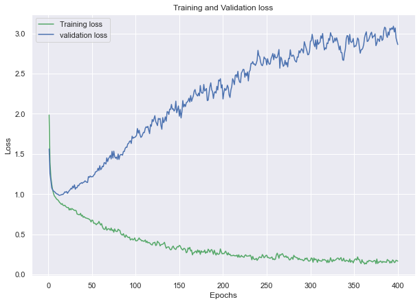

```python
loss_train = NNclassifier.history['loss']
loss_val = NNclassifier.history['val_loss']
epochs = range(1,401)
plt.plot(epochs, loss_train, 'g', label='Training loss')
plt.plot(epochs, loss_val, 'b', label='validation loss')
plt.title('Training and Validation loss')
plt.xlabel('Epochs')
plt.ylabel('Loss')
plt.legend()
plt.show()
```

ii) Training Accuracy and Validation Accuracy

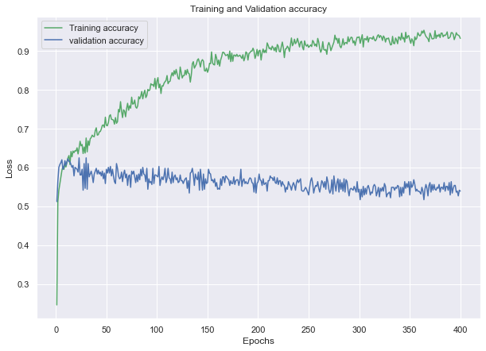

```python
loss_train = NNclassifier.history['accuracy']
loss_val = NNclassifier.history['val_accuracy']
epochs = range(1,401)
plt.plot(epochs, loss_train, 'g', label='Training accuracy')
plt.plot(epochs, loss_val, 'b', label='validation accuracy')
plt.title('Training and Validation accuracy')
plt.xlabel('Epochs')
plt.ylabel('Loss')
plt.legend()
plt.show()
```

### Part1.3d -Design new architecture/update existing architecture in attempt to improve the performance of the model

```python
neuralclass1 = Sequential()

#input layer
neuralclass1.add(Dense(128, input_dim = Xc_train.shape[1],activation='sigmoid'))

#hidden layer
neuralclass1.add(Dense(64, activation='tanh'))
neuralclass1.add(Dropout(0.2))
neuralclass1.add(Dense(32, activation='tanh'))
neuralclass1.add(Dense(16, activation='relu'))

neuralclass1.add(Dense(9, activation='softmax'))
neuralclass1.compile(loss="categorical_crossentropy", metrics=["accuracy"], optimizer="sgd")
```

```python
NNclassifier1=neuralclass1.fit(x=Xc_Train_S,y=Yc_train,batch_size=20, epochs=400,validation_data=(Xc_Test_S,Yc_test))
```